# Clonal memory simulations

## Initial assumptions

- 2 processes: division and differentiation.
- No cell death.
- 2 types of cells: A and B.
- A → B: A can differentiate into B, B cannot differentiate into A (no de-differentiation).
- The simulation starts with N0 initial cells of type A (meaning there are N0 families).
- The simulation ends when N cells are reached in total (there will not be N cells exactly, it stops when it gets the closest possible to N).
- Division times are sampled from a Log-Normal probability distribution (with parameters taken from experiments).
- This distribution is the same independently of the cell type, family, generation etc.
- Differentiation can only happen with division. No differentiation without division.
- After each type A cell division there are 3 possibilities: AA, AB and BB.
- Small differentiation probability D: (100-D)% AA, (D/2)% AB (D/2)% BB.
- After each type B cell division there is only one possibility: BB.
- **No differentiation memory** (clonal memory has no effect on differentiation).
- **Perfect division memory** (clonal memory has an effect on division):
  - division time is exactly equal for cells of the same generation of the same family (deriving from the same initial cell), meaning that within a family all cells divide synchronously and after each round of divisions a single division time is sampled from the distribution.
  - division memory is over all generations.
- Steps of 30 minutes.
- Initialization: N0 division times are sampled from the distribution (one division time for each initial cell).
- The simulation starts and each initial cell divides at her division time.
- After every division a new division time is sampled from the distribution etc. ...

## Import Libraries

```python
import numpy as np
import matplotlib.pyplot as plt
```

## Parameters

They will change for different simulations

```python
TIME_STEP = 0.5  # 30 min (in hours)

N_INITIAL_CELLS = 5 # = number of families (N0)
N_FINAL_CELLS = 1000 # the simulation will stop when this number of cells (at least) is reached (N)
DIFF_PERC = 0.02 # if 0.02 then: AB 1% prob and BB 1% prob (D)

# from experimental data:
MU = 2.83 # (mean value between all T2 and T3)
SIGMA = 0.42 #  (largest value between all)
# with these values the lognormal distribution has: mean = 18.46 hours, std = 8.05 hours
# see details in 'lognormal_fit'
```

## Functions

### Single run function

With or without memory depending on the variable MEMORY

```python
def single_run(MEMORY, TIME_STEP, N_INITIAL_CELLS, N_FINAL_CELLS, DIFF_PERC, MU, SIGMA):



    if MEMORY == True:


        # ------------- CELL CLASS -------------

        class Cell:
            def __init__(self, type):
                self.type = type # 'A' or 'B'
                # ADD more variables to characterize a cell if needed


        # ------------- INITIALIZATION -------------

        time = 0.0

        # current state of the system, updated at each division
        fam = {f'F{i + 1}': {'cells': [],
                             'current_gen': 0,
                             'next_div': 0.0,
                             # ADD more key-values if needed
                             } for i in range(N_INITIAL_CELLS)}

        # initialization of fam
        for f in fam.keys():
            fam[f]['cells'].append(Cell(type='A'))  # CHANGE if different initial configuration
            fam[f]['next_div'] = np.random.lognormal(mean=MU, sigma=SIGMA)
        # print(fam)

        # to track variables (number of A cells, number of B cells, current generation) over time for each family
        history = {f: [[time, 1, 0, 0]] for f in fam.keys()}  # CHANGE if different initial configuration
        # ADD more variables to track if needed
        # print(history)

        N_current_cells = N_INITIAL_CELLS

        # -error is the difference between N_FINAL_CELLS and the current number of cells
        # -it tells us how much we are close to the desired final number of cells (with memory impossible to get exactly N_FINAL_CELLS in the end)
        # -we want to stop the simulation when this error is the lowest possible

        error_new = N_FINAL_CELLS - N_INITIAL_CELLS  # initial error
        error_old = N_FINAL_CELLS  # (set just to enter the first if)

        fam_old = {}  # to be able to go one step back in time if the error increases


        # ------------- SIMULATION -------------

        while N_current_cells < N_FINAL_CELLS:  # it stops when N_current_cells >= N_FINAL_CELLS

            # 1) set fam_old = fam
            if error_new < error_old:  # if error_new == error_old it means that at the previous step there has not been divisions therefore it is not necessary to update fam_old
                # (error_new > error_old means that N_FINAL_CELLS has been reached therefore it is impossible to enter the while loop and this condition never happens)
                fam_old = { f: { 'cells': fam[f]['cells'][:],
                                 'current_gen': fam[f]['current_gen'],
                                 'next_div': fam[f]['next_div']  } for f in fam }

            # 2) fam update (also time and history)
            time += TIME_STEP

            for f in fam.keys():

                while fam[f]['next_div'] <= time:  # if this holds, all cells (within the family) divide
                    # (while because there can be two divisions within same time step if the division time sampled is < 0.5, rare but in theory it could happen)

                    fam[f]['current_gen'] += 1  # UPDATE generation

                    #print(f'Division round {fam[f]['current_gen']} for family {f} at time {round(fam[f]['next_div'], 2)}')

                    div_time = np.random.lognormal(mean=MU, sigma=SIGMA)
                    fam[f]['next_div'] = fam[f]['next_div'] + div_time  # UPDATE time of the next division

                    cells = fam[f]['cells']
                    new_cells = []

                    for cell in cells:
                        if cell.type == 'A':
                            outcome = np.random.choice(['AA', 'AB', 'BB'], p=[1 - DIFF_PERC, DIFF_PERC / 2, DIFF_PERC / 2])  # CHANGE to have different differentiation probabilities
                            if outcome == 'AA':
                                new_cells.extend([Cell(type='A'), Cell(type='A')])
                            elif outcome == 'AB':
                                new_cells.extend([Cell(type='A'), Cell(type='B')])
                            elif outcome == 'BB':
                                new_cells.extend([Cell(type='B'), Cell(type='B')])
                        elif cell.type == 'B':
                            new_cells.extend([Cell(type='B'), Cell(type='B')])

                    fam[f]['cells'] = new_cells  # UPDATE cells

                N_type_A = sum(1 for cell in fam[f]['cells'] if cell.type == 'A')
                N_type_B = sum(1 for cell in fam[f]['cells'] if cell.type == 'B')
                history[f].append([time, N_type_A, N_type_B, fam[f]['current_gen']])  # EXTEND history

            # 3) set error_old = error_new
            error_old = error_new

            # 4) error_new update
            N_current_cells = sum(history[f][-1][1] + history[f][-1][2] for f in fam.keys())
            error_new = abs(N_FINAL_CELLS - N_current_cells)

        if error_new > error_old:
            # one step back in time in order to stop the simulation when the error is the lowest
            time -= TIME_STEP
            for f in fam.keys():
                fam[f]['cells'] = fam_old[f]['cells']
                fam[f]['current_gen'] = fam_old[f]['current_gen']
                fam[f]['next_div'] = fam_old[f]['next_div']
                history[f].pop()
            N_current_cells = sum(history[f][-1][1] + history[f][-1][2] for f in fam.keys())
            #print('error_new > error_old, let\'s do one step back in time!')  # UNCOMMENT IF NEEDED

        elif error_new == error_old:  # in case the errors above and below N_FINAL_CELLS are equal, we throw a coin to choose
            outcome = np.random.choice(['below', 'above'], p=[0.5, 0.5])
            if outcome == 'below':
                # one step back in time in order to stop the simulation when the error is the lowest
                time -= TIME_STEP
                for f in fam.keys():
                    fam[f]['cells'] = fam_old[f]['cells']
                    fam[f]['current_gen'] = fam_old[f]['current_gen']
                    fam[f]['next_div'] = fam_old[f]['next_div']
                    history[f].pop()
                N_current_cells = sum(history[f][-1][1] + history[f][-1][2] for f in fam.keys())
            #print(f'error_new = error_old and the outcome is {outcome}!')  # UNCOMMENT IF NEEDED
```

```python
    elif MEMORY == False:


        # ------------- CELL CLASS -------------

        class Cell:
            def __init__(self, type, next_div, current_gen):
                self.type = type # 'A' or 'B'
                self.next_div = next_div
                self.current_gen = current_gen
                # ADD more variables to characterize a cell if needed


        # ------------- INITIALIZATION -------------

        time = 0.0

        # current state of the system, updated at each division
        fam = { f'F{i+1}': { 'cells': [],
                            #ADD more key-values if needed
                            } for i in range(N_INITIAL_CELLS) }

        # initialization of fam
        for f in fam.keys():
            div_time = np.random.lognormal(mean=MU, sigma=SIGMA)
            fam[f]['cells'].append(Cell(type='A', next_div=div_time, current_gen=0)) # CHANGE if different initial configuration
        #print(fam)

        # to track variables (number of A cells, number of B cells, current generation mean, current generation std) over time for each family
        history = { f : [ [time, 1, 0, 0, 0] ] for f in fam.keys() } # CHANGE if different initial configuration
        # ADD more variables to track if needed
        #print(history)

        N_current_cells = N_INITIAL_CELLS

        # -error is the difference between N_FINAL_CELLS and the current number of cells
        # -it tells us how much we are close to the desired final number of cells (with memory impossible to get exactly N_FINAL_CELLS in the end)
        # -we want to stop the simulation when this error is the lowest possible

        error_new = N_FINAL_CELLS - N_INITIAL_CELLS  # initial error
        error_old = N_FINAL_CELLS  # (set just to enter the first if)

        fam_old = {}  # to be able to go one step back in time if the error increases


        # ------------- SIMULATION -------------

        while N_current_cells < N_FINAL_CELLS:  # it stops when N_current_cells >= N_FINAL_CELLS

            # 1) set fam_old = fam
            if error_new < error_old:  # if error_new == error_old it means that at the previous step there has not been divisions therefore it is not necessary to update fam_old
                # (error_new > error_old means that N_FINAL_CELLS has been reached therefore it is impossible to enter the while loop and this condition never happens)
                fam_old = { f: { 'cells': fam[f]['cells'][:] } for f in fam }

            # 2) fam update (also time and history)
            time += TIME_STEP

            for f in fam.keys():

                cells = fam[f]['cells']

                divided = []
                not_divided = []

                div_finish = False
                while div_finish == False:

                    for cell in cells:

                        if cell.next_div <= time: # if this holds, the cell divides (the daughter cells are added to divided)

                            #print(f'A cell is dividing in family {f} at time {round(cell.next_div, 2)}')

                            div_time_1 = np.random.lognormal(mean=MU, sigma=SIGMA)
                            div_time_2 = np.random.lognormal(mean=MU, sigma=SIGMA)

                            if cell.type == 'A':
                                outcome = np.random.choice(['AA', 'AB', 'BB'], p=[1-DIFF_PERC, DIFF_PERC/2, DIFF_PERC/2]) # CHANGE to have a different distribution
                                if outcome == 'AA':
                                    divided.extend([Cell(type='A', next_div=cell.next_div + div_time_1, current_gen=cell.current_gen + 1), Cell(type='A', next_div=cell.next_div + div_time_2, current_gen=cell.current_gen + 1)])
                                elif outcome == 'AB':
                                    divided.extend([Cell(type='A', next_div=cell.next_div + div_time_1, current_gen=cell.current_gen + 1), Cell(type='B', next_div=cell.next_div + div_time_2, current_gen=cell.current_gen + 1)])
                                elif outcome == 'BB':
                                    divided.extend([Cell(type='B', next_div=cell.next_div + div_time_1, current_gen=cell.current_gen + 1), Cell(type='B', next_div=cell.next_div + div_time_2, current_gen=cell.current_gen + 1)])
                            elif cell.type == 'B':
                                divided.extend([Cell(type='B', next_div=cell.next_div + div_time_1, current_gen=cell.current_gen + 1), Cell(type='B', next_div=cell.next_div + div_time_2, current_gen=cell.current_gen + 1)])

                        elif cell.next_div > time: # if this holds, the cell doesn't divide (the cell is added to not_divided)
                            not_divided.append(cell)

                    if divided == []:
                        div_finish = True
                    elif divided != []: # if this holds, we need to check if the next division time of the new cells <= time, in that case they divide again
                        cells = divided
                        divided = []

                fam[f]['cells'] = divided + not_divided # UPDATE cells

                gens = []
                for cell in fam[f]['cells']:
                    gens.append(cell.current_gen)

                N_type_A = sum(1 for cell in fam[f]['cells'] if cell.type == 'A')
                N_type_B = sum(1 for cell in fam[f]['cells'] if cell.type == 'B')
                history[f].append( [time, N_type_A, N_type_B, np.mean(gens), np.std(gens)] ) # EXTEND history

            # 3) set error_old = error_new
            error_old = error_new

            # 4) error_new update
            N_current_cells = sum(history[f][-1][1] + history[f][-1][2] for f in fam.keys())
            error_new = abs(N_FINAL_CELLS - N_current_cells)

        if error_new > error_old:
            # one step back in time in order to stop the simulation when the error is the lowest
            time -= TIME_STEP
            for f in fam.keys():
                fam[f]['cells'] = fam_old[f]['cells']
                history[f].pop()
            N_current_cells = sum(history[f][-1][1] + history[f][-1][2] for f in fam.keys())
            #print('error_new > error_old, let\'s do one step back in time!')  # UNCOMMENT IF NEEDED
```

```python
        elif error_new == error_old:  # in case the errors above and below N_FINAL_CELLS are equal, we throw a coin to choose
            outcome = np.random.choice(['below', 'above'], p=[0.5, 0.5])
            if outcome == 'below':
                # one step back in time in order to stop the simulation when the error is the lowest
                time -= TIME_STEP
                for f in fam.keys():
                    fam[f]['cells'] = fam_old[f]['cells']
                    history[f].pop()
                N_current_cells = sum(history[f][-1][1] + history[f][-1][2] for f in fam.keys())
            #print(f'error_new = error_old and the outcome is {outcome}!')  # UNCOMMENT IF NEEDED



    return fam, history, time # (time is when the simulation stops)
```

### Function extracting final values

From single run outputs

```python
def get_final_values(history):

    N_type_A_fam = []
    N_type_B_fam = []
    frac_type_A_fam = []
    frac_type_B_fam = []
    for f in history.keys():
        N_type_A_fam.append(history[f][-1][1])
        N_type_B_fam.append(history[f][-1][2])
        frac_type_A_fam.append(history[f][-1][1] / (history[f][-1][1] + history[f][-1][2]))
        frac_type_B_fam.append(history[f][-1][2] / (history[f][-1][1] + history[f][-1][2]))
    N_type_A = sum(N_type_A_fam)
    N_type_B = sum(N_type_B_fam)
    frac_type_A = N_type_A / (N_type_A + N_type_B)
    frac_type_B = N_type_B / (N_type_A + N_type_B)

    # ADD more final values if needed

    return N_type_A, N_type_B, N_type_A_fam, N_type_B_fam, frac_type_A, frac_type_B, frac_type_A_fam, frac_type_B_fam
```

### Multiple runs function

With or without memory depending on the variable MEMORY

```python
def multiple_runs(N_RUNS, MEMORY, TIME_STEP, N_INITIAL_CELLS, N_FINAL_CELLS, DIFF_PERC, MU, SIGMA):

    d = {} # dictionary to collect outputs

    fams, histories, times = [], [], []
    N_type_A_list, N_type_B_list, N_tot_list = [], [], []
    N_type_A_fam_list, N_type_B_fam_list, N_tot_fam_list = [], [], []
    frac_type_A_list, frac_type_B_list = [], []
    frac_type_A_fam_list, frac_type_B_fam_list = [], []
    range_num_list = []
    range_frac_list = []
    stdfam_num_list = []
    stdfam_frac_list = []
    range_over_mean_num_list = []
    stdfam_over_mean_num_list = []
    N_tot_fam_std_list = []

    for i in range(N_RUNS):

        fam, history, time = single_run(MEMORY, TIME_STEP, N_INITIAL_CELLS, N_FINAL_CELLS, DIFF_PERC, MU, SIGMA)

        fams.append(fam)
        histories.append(history)
        times.append(time)

        N_type_A, N_type_B, N_type_A_fam, N_type_B_fam, frac_type_A, frac_type_B, frac_type_A_fam, frac_type_B_fam = get_final_values(history)

        N_type_A_list.append(N_type_A)
        N_type_B_list.append(N_type_B)
        N_type_A_fam_list.append(N_type_A_fam)
        N_type_B_fam_list.append(N_type_B_fam)

        N_tot_list.append(N_type_A + N_type_B)

        N_tot_fam = np.array(N_type_A_fam) + np.array(N_type_B_fam)
        N_tot_fam_list.append(list(N_tot_fam))

        frac_type_A_list.append(frac_type_A)
        frac_type_B_list.append(frac_type_B)
        frac_type_A_fam_list.append(frac_type_A_fam)
        frac_type_B_fam_list.append(frac_type_B_fam)

        range_num_list.append( max(N_tot_fam) - min(N_tot_fam) )
        range_frac_list.append( max(frac_type_A_fam) - min(frac_type_A_fam) )

        range_over_mean_num_list.append( (max(N_tot_fam) - min(N_tot_fam)) / np.mean( N_tot_fam ) )

        stdfam_num = np.std( N_tot_fam )
        stdfam_frac = np.std( frac_type_A_fam )
        stdfam_num_list.append( stdfam_num )
        stdfam_frac_list.append( stdfam_frac )

        stdfam_over_mean_num_list.append(np.std( N_tot_fam ) / np.mean( N_tot_fam ) )

        N_tot_fam_std_list.append(np.std(N_tot_fam))

    d['N_type_A_fam_list'] = N_type_A_fam_list
    d['N_type_B_fam_list'] = N_type_B_fam_list
    d['N_tot_fam_list'] = N_tot_fam_list
    d['frac_type_A_fam_list'] = frac_type_A_fam_list
    d['frac_type_B_fam_list'] = frac_type_B_fam_list

    d['N_tot_list'] = N_tot_list
    d['frac_type_A_list'] = frac_type_A_list
    d['frac_type_B_list'] = frac_type_B_list

    d['range_num_list'] = range_num_list
    d['range_frac_list'] = range_frac_list

    d['stdfam_num_list'] = stdfam_num_list
    d['stdfam_frac_list'] = stdfam_frac_list

    # all these lists saved as outputs are for boxplots

    d['N_type_A_mean'] = np.mean(N_type_A_list)
    d['N_type_B_mean'] = np.mean(N_type_B_list)
    d['N_type_A_std'] = np.std(N_type_A_list)
    d['N_type_B_std'] = np.std(N_type_B_list)

    N_tot_list = np.array(N_type_A_list) + np.array(N_type_B_list) # not in return
    d['N_tot_std'] = np.std(N_tot_list)

    d['N_type_A_mean_fam'] = np.mean(np.array(N_type_A_fam_list), axis=0) # (axis=0 per far la media per colonne)
    d['N_type_B_mean_fam'] = np.mean(np.array(N_type_B_fam_list), axis=0)
    d['N_type_A_std_fam'] = np.std(np.array(N_type_A_fam_list), axis=0)
    d['N_type_B_std_fam'] = np.std(np.array(N_type_B_fam_list), axis=0)

    d['N_tot_std_fam'] = np.std(np.array(N_tot_fam_list), axis=0)

    d['frac_type_A_mean'] = np.mean(frac_type_A_list)
    d['frac_type_B_mean'] = np.mean(frac_type_B_list)
    d['frac_type_A_std'] = np.std(frac_type_A_list)
    d['frac_type_B_std'] = np.std(frac_type_B_list)

    d['frac_type_A_mean_fam'] = np.mean(np.array(frac_type_A_fam_list), axis=0)
    d['frac_type_B_mean_fam'] = np.mean(np.array(frac_type_B_fam_list), axis=0)
    d['frac_type_A_std_fam'] = np.std(np.array(frac_type_A_fam_list), axis=0)
    d['frac_type_B_std_fam'] = np.std(np.array(frac_type_B_fam_list), axis=0)

    d['range_num_mean'] = np.mean(range_num_list)
    d['range_num_std'] = np.std(range_num_list)
    d['range_frac_mean'] = np.mean(range_frac_list)
    d['range_frac_std'] = np.std(range_frac_list)

    d['range_over_mean_num_mean'] = np.mean(range_over_mean_num_list)
    d['range_over_mean_num_std'] = np.std(range_over_mean_num_list)

    d['stdfam_num_mean'] = np.mean(stdfam_num_list)
    d['stdfam_num_std'] = np.std(stdfam_num_list)
    d['stdfam_frac_mean'] = np.mean(stdfam_frac_list)
    d['stdfam_frac_std'] = np.std(stdfam_frac_list)

    d['stdfam_over_mean_num_mean'] = np.mean(stdfam_over_mean_num_list)
    d['stdfam_over_mean_num_std'] = np.std(stdfam_over_mean_num_list)

    d['N_tot_fam_std_mean'] = np.mean(N_tot_fam_std_list)
    d['N_tot_fam_std_std'] = np.std(N_tot_fam_std_list)

    # ADD more outputs to d if needed

    return fams, histories, times, d
```

## Memory

```python
MEMORY = False
```

## Single run simulation

```python
TIME_STEP = 0.5
N_INITIAL_CELLS = 4
N_FINAL_CELLS = 100000
DIFF_PERC = 0.02
MU = 2.83
SIGMA = 0.42

fam, history, time = single_run(MEMORY, TIME_STEP, N_INITIAL_CELLS, N_FINAL_CELLS, DIFF_PERC, MU, SIGMA)
N_type_A, N_type_B, N_type_A_fam, N_type_B_fam, frac_type_A, frac_type_B, frac_type_A_fam, frac_type_B_fam = get_final_values(history)
```

### Print

```python
print(f'--Simulation stopped at time: {time}\n')

print('--Number of final cells:')
print(f'A = {N_type_A}, B = {N_type_B}, Total = {N_type_A + N_type_B}')
print('--Number of final cells per family:')
N_A_fam, N_B_fam, N_tot_fam = [], [], []
for i, f in enumerate(fam.keys()):
    print(f'{f}: A = {N_type_A_fam[i]}, B = {N_type_B_fam[i]}, Total = {N_type_A_fam[i] + N_type_B_fam[i]}')
    N_A_fam.append(N_type_A_fam[i])
    N_B_fam.append(N_type_B_fam[i])
    N_tot_fam.append(N_type_A_fam[i] + N_type_B_fam[i])
print(f'(Mean between families: A = {round(np.mean(N_A_fam), 2)}, B = {round(np.mean(N_B_fam), 2)}, Total = {round(np.mean(N_tot_fam), 2)})')
print(f'(Std between families: A = {round(np.std(N_A_fam), 2)}, B = {round(np.std(N_B_fam), 2)}, Total = {round(np.std(N_tot_fam), 2)})\n')

print('--Fraction of final cells:')
print(f'A = {round(frac_type_A, 2)}, B = {round(frac_type_B, 2)}')
print('--Fraction of final cells per family:')
frac_A_fam, frac_B_fam = [], []
for i, f in enumerate(fam.keys()):
    print(f'{f}: A = {round(frac_type_A_fam[i], 2)}, B = {round(frac_type_B_fam[i], 2)}')
    frac_A_fam.append(frac_type_A_fam[i])
    frac_B_fam.append(frac_type_B_fam[i])
print(f'(Mean between families: A = {round(np.mean(frac_A_fam), 2)}, B = {round(np.mean(frac_B_fam), 2)})')
print(f'(Std between families: A = {round(np.std(frac_A_fam), 2)}, B = {round(np.std(frac_B_fam), 2)})\n')

if MEMORY == True:
    gen_fam = []
    print('--Generation of final cells per family (=number of division rounds performed per family):')
    for f in fam.keys():
        print(f'{f}: {fam[f]['current_gen']}')
        gen_fam.append(fam[f]['current_gen'])
    print(f'(Mean between families: {round(np.mean(gen_fam), 2)})')
    print(f'(Std between families: {round(np.std(gen_fam), 2)})\n')
elif MEMORY==False:
    gen_fam = []
    print('--Average generation of final cells per family (=average number of division rounds performed per family):')
    for f in fam.keys():
        print(f'{f}: {round(history[f][-1][3], 2)} (std = {round(history[f][-1][4], 2)})')
        gen_fam.append(history[f][-1][3])
    print(f'(Mean between families: {round(np.mean(gen_fam), 2)})')
    print(f'(Std between families: {round(np.std(gen_fam), 2)})\n')
```

```
--Simulation stopped at time: 271.0

--Number of final cells:
A = 86720, B = 14009, Total = 100729
--Number of final cells per family:
F1: A = 39183, B = 5402, Total = 44585
F2: A = 4165, B = 504, Total = 4669
F3: A = 24647, B = 3146, Total = 27793
F4: A = 18725, B = 4957, Total = 23682
(Mean between families: A = 21680.0, B = 3502.25, Total = 25182.25)
(Std between families: A = 12556.53, B = 1926.25, Total = 14197.95)

--Fraction of final cells:
A = 0.86, B = 0.14
--Fraction of final cells per family:
F1: A = 0.88, B = 0.12
F2: A = 0.89, B = 0.11
F3: A = 0.89, B = 0.11
F4: A = 0.79, B = 0.21
(Mean between families: A = 0.86, B = 0.14)
(Std between families: A = 0.04, B = 0.04)

--Average generation of final cells per family (=average number of division rounds performed per family):
F1: 16.17 (std = 1.48)
F2: 12.87 (std = 1.37)
F3: 15.63 (std = 1.6)
F4: 15.29 (std = 1.52)
(Mean between families: 14.99)
(Std between families: 1.27)
```

### Plots 1 - final quantities

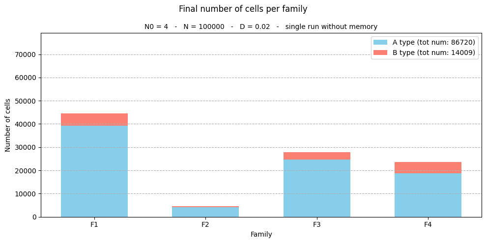

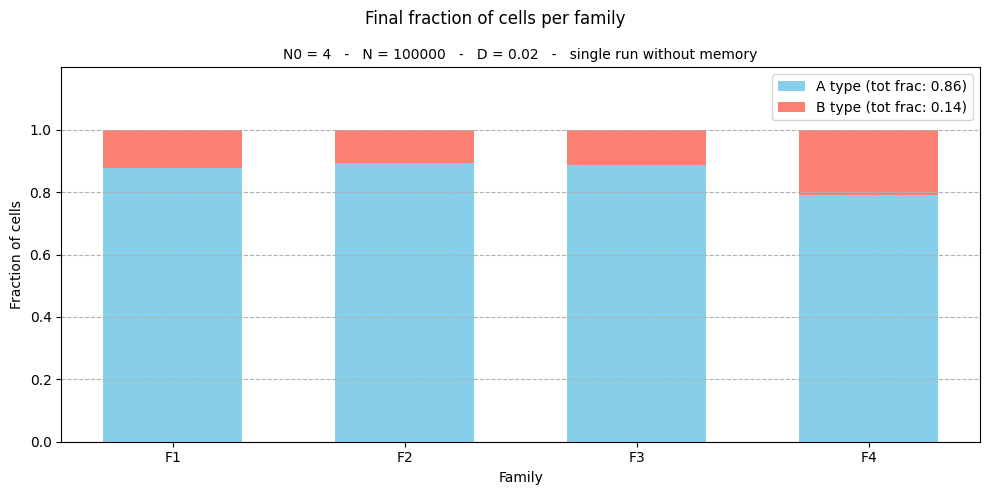

```python
#plot 1
width = 0.6
plt.figure(figsize=(10, 5))
plt.bar(list(history.keys()), N_type_A_fam, width, label=f'A type (tot num: {round(N_type_A, 2)})', color='skyblue')
plt.bar(list(history.keys()), N_type_B_fam, width, bottom=N_type_A_fam, label=f'B type (tot num: {round(N_type_B, 2)})', color='salmon')
plt.ylabel('Number of cells')
plt.xlabel('Family')
plt.suptitle('Final number of cells per family')
if MEMORY == True:
    plt.title( f'N0 = {N_INITIAL_CELLS}   -   N = {N_FINAL_CELLS}   -   D = {DIFF_PERC}   -   single run with memory', fontsize=10)
elif MEMORY == False:
    plt.title( f'N0 = {N_INITIAL_CELLS}   -   N = {N_FINAL_CELLS}   -   D = {DIFF_PERC}   -   single run without memory', fontsize=10)
plt.legend()
plt.grid(axis='y', linestyle='--')
plt.ylim(top=plt.ylim()[1] * 1.15)
plt.tight_layout()
plt.ylim((np.float64(0.0), np.float64(79134.72))) # pasted from memory to have plots in the same scale
plt.show()

#plot 2
width = 0.6
plt.figure(figsize=(10, 5))
plt.bar(list(history.keys()), frac_type_A_fam, width, label=f'A type (tot frac: {round(frac_type_A, 2)})', color='skyblue')
plt.bar(list(history.keys()), frac_type_B_fam, width, bottom=frac_type_A_fam, label=f'B type (tot frac: {round(frac_type_B, 2)})', color='salmon')
plt.ylabel('Fraction of cells')
plt.xlabel('Family')
plt.suptitle('Final fraction of cells per family')
if MEMORY == True:
    plt.title( f'N0 = {N_INITIAL_CELLS}   -   N = {N_FINAL_CELLS}   -   D = {DIFF_PERC}   -   single run with memory', fontsize=10)
elif MEMORY == False:
    plt.title( f'N0 = {N_INITIAL_CELLS}   -   N = {N_FINAL_CELLS}   -   D = {DIFF_PERC}   -   single run without memory', fontsize=10)
plt.legend()
plt.grid(axis='y', linestyle='--')
plt.ylim(0, 1.2)
plt.yticks([0, 0.2, 0.4, 0.6, 0.8, 1])
plt.tight_layout()
plt.show()
```

### Plots 2 - time evolutions per family and cell type

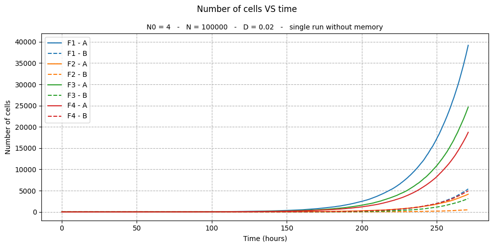

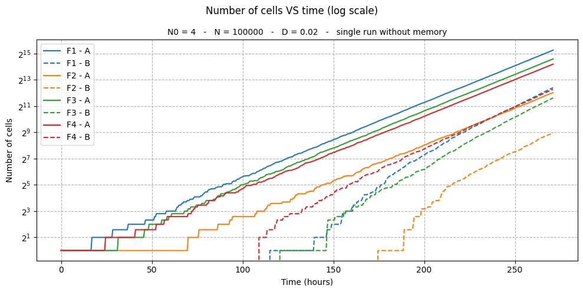

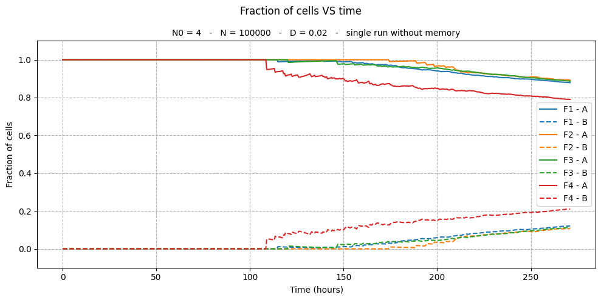

```python
#plot 1
plt.figure(figsize=(10, 5))
for f, data in history.items():
    plt.plot([t[0] for t in data], [t[1] for t in data], label=f'{f} - A', linestyle='-')
    plt.plot([t[0] for t in data], [t[2] for t in data], label=f'{f} - B', linestyle='--', color=plt.gca().lines[-1].get_color())
plt.xlabel('Time (hours)')
plt.ylabel('Number of cells')
plt.suptitle('Number of cells VS time')
if MEMORY == True:
    plt.title( f'N0 = {N_INITIAL_CELLS}   -   N = {N_FINAL_CELLS}   -   D = {DIFF_PERC}   -   single run with memory', fontsize=10)
elif MEMORY == False:
    plt.title( f'N0 = {N_INITIAL_CELLS}   -   N = {N_FINAL_CELLS}   -   D = {DIFF_PERC}   -   single run without memory', fontsize=10)
plt.legend()
plt.grid(linestyle='--')
plt.tight_layout()
plt.ylim((np.float64(-1996.7), np.float64(41930.7))) # pasted from memory to have plots in the same scale
plt.show()

#plot 2
plt.figure(figsize=(10, 5))
for f, data in history.items():
    plt.plot([t[0] for t in data], [t[1] for t in data], label=f'{f} - A', linestyle='-')
    plt.plot([t[0] for t in data], [t[2] for t in data], label=f'{f} - B', linestyle='--', color=plt.gca().lines[-1].get_color())
plt.xlabel('Time (hours)')
plt.ylabel('Number of cells')
plt.suptitle('Number of cells VS time (log scale)')
if MEMORY == True:
    plt.title( f'N0 = {N_INITIAL_CELLS}   -   N = {N_FINAL_CELLS}   -   D = {DIFF_PERC}   -   single run with memory', fontsize=10)
elif MEMORY == False:
    plt.title( f'N0 = {N_INITIAL_CELLS}   -   N = {N_FINAL_CELLS}   -   D = {DIFF_PERC}   -   single run without memory', fontsize=10)
plt.legend()
plt.grid(linestyle='--')
plt.yscale('log', base=2)
plt.tight_layout()
plt.ylim((np.float64(0.5887526288536101), np.float64(67828.14724370312))) # pasted from memory to have plots in the same scale
plt.show()

#plot 3
plt.figure(figsize=(10, 5))
for f, data in history.items():
    plt.plot([t[0] for t in data], [ (t[1] / (t[1]+t[2])) for t in data], label=f'{f} - A', linestyle='-')
    plt.plot([t[0] for t in data], [ (t[2] / (t[1]+t[2])) for t in data], label=f'{f} - B', linestyle='--', color=plt.gca().lines[-1].get_color())
    #plt.plot([t[0] for t in data], np.array([ (t[1] / (t[1]+t[2])) for t in data]) + np.array([ (t[2] / (t[1]+t[2])) for t in data]), linestyle='-', color='grey') # just to check
plt.xlabel('Time (hours)')
plt.ylabel('Fraction of cells')
plt.suptitle('Fraction of cells VS time')
if MEMORY == True:
    plt.title( f'N0 = {N_INITIAL_CELLS}   -   N = {N_FINAL_CELLS}   -   D = {DIFF_PERC}   -   single run with memory', fontsize=10)
elif MEMORY == False:
    plt.title( f'N0 = {N_INITIAL_CELLS}   -   N = {N_FINAL_CELLS}   -   D = {DIFF_PERC}   -   single run without memory', fontsize=10)
plt.legend()
plt.grid(linestyle='--')
plt.ylim(-0.1, 1.1)
plt.yticks([0, 0.2, 0.4, 0.6, 0.8, 1])
plt.tight_layout()
plt.show()
```

### Plots 3 - time evolutions per family

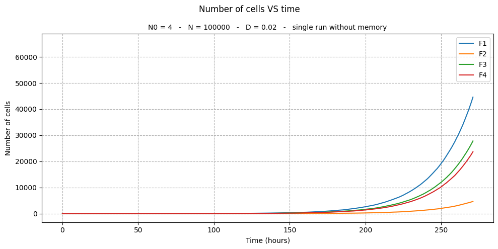

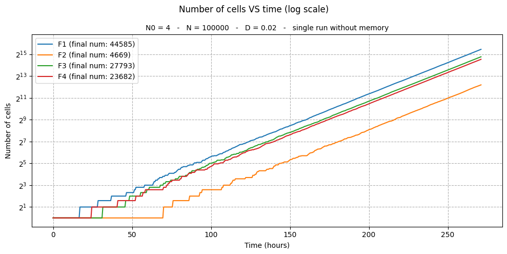

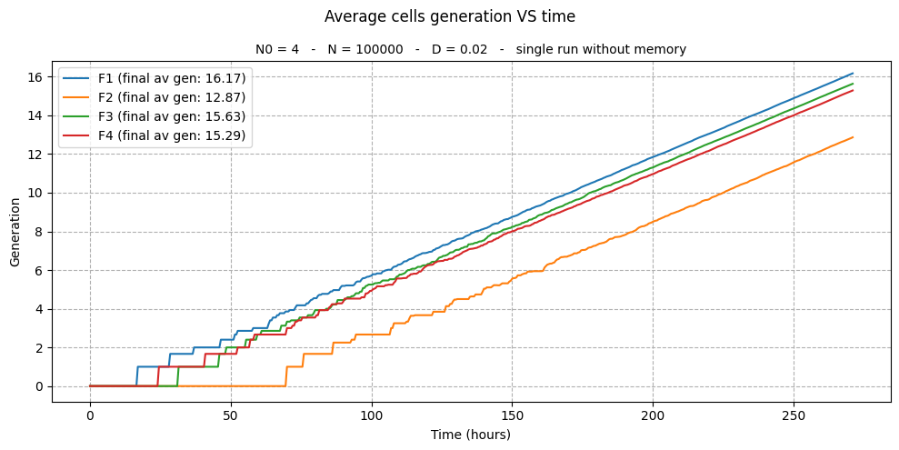

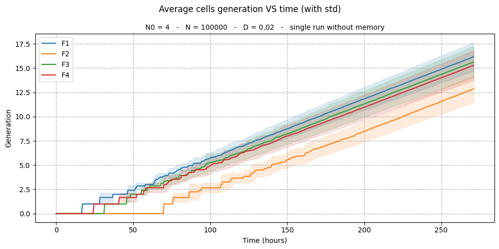

```python
#plot 1
plt.figure(figsize=(10, 5))
for f, data in history.items():
    plt.plot([t[0] for t in data], [t[1]+t[2] for t in data], label=f'{f}')
plt.xlabel("Time (hours)")
plt.ylabel("Number of cells")
plt.suptitle('Number of cells VS time')
if MEMORY == True:
    plt.title( f'N0 = {N_INITIAL_CELLS}   -   N = {N_FINAL_CELLS}   -   D = {DIFF_PERC}   -   single run with memory', fontsize=10)
elif MEMORY == False:
    plt.title( f'N0 = {N_INITIAL_CELLS}   -   N = {N_FINAL_CELLS}   -   D = {DIFF_PERC}   -   single run without memory', fontsize=10)
plt.legend()
plt.grid(linestyle='--')
plt.tight_layout()
plt.ylim((np.float64(-3275.75), np.float64(68812.75))) # pasted from memory to have plots in the same scale
plt.show()

#plot 2
plt.figure(figsize=(10, 5))
for f, data in history.items():
    plt.plot([t[0] for t in data], [t[1]+t[2] for t in data], label=f'{f} (final num: {history[f][-1][1] + history[f][-1][2]})')
plt.xlabel("Time (hours)")
plt.ylabel("Number of cells")
plt.suptitle('Number of cells VS time (log scale)')
if MEMORY == True:
    plt.title( f'N0 = {N_INITIAL_CELLS}   -   N = {N_FINAL_CELLS}   -   D = {DIFF_PERC}   -   single run with memory', fontsize=10)
elif MEMORY == False:
    plt.title( f'N0 = {N_INITIAL_CELLS}   -   N = {N_FINAL_CELLS}   -   D = {DIFF_PERC}   -   single run without memory', fontsize=10)
plt.legend()
plt.grid(linestyle='--')
plt.yscale('log', base=2)
plt.tight_layout()
plt.ylim((np.float64(0.5743491774985174), np.float64(114104.80343234964))) # pasted from memory to have plots in the same scale
plt.show()

if MEMORY==True:
    #plot 3
    plt.figure(figsize=(10, 5))
    for f, data in history.items():
        plt.plot([t[0] for t in data], [t[3] for t in data], label=f'{f} (final gen: {history[f][-1][3]})')
    plt.xlabel("Time (hours)")
    plt.ylabel("Generation")
    plt.suptitle('Cells generation VS time')
    plt.title( f'N0 = {N_INITIAL_CELLS}   -   N = {N_FINAL_CELLS}   -   D = {DIFF_PERC}   -   single run with memory', fontsize=10)
    plt.legend()
    plt.grid(linestyle='--')
    plt.tight_layout()
    plt.show()

if MEMORY==False:
    #plot 3
    plt.figure(figsize=(10, 5))
    for f, data in history.items():
        plt.plot([t[0] for t in data], [t[3] for t in data], label=f'{f} (final av gen: {round(history[f][-1][3], 2)})')
    plt.xlabel("Time (hours)")
    plt.ylabel("Generation")
    plt.suptitle('Average cells generation VS time')
    plt.title( f'N0 = {N_INITIAL_CELLS}   -   N = {N_FINAL_CELLS}   -   D = {DIFF_PERC}   -   single run without memory', fontsize=10)
    plt.legend()
    plt.grid(linestyle='--')
    plt.tight_layout()
    plt.ylim((np.float64(-0.8), np.float64(16.8))) # pasted from memory to have plots in the same scale
    plt.show()

    #plot 4
    plt.figure(figsize=(10, 5))
    for f, data in history.items():
        plt.plot([t[0] for t in data], [t[3] for t in data], label=f'{f}')
        plt.fill_between([t[0] for t in data], np.array([t[3] for t in data]) - np.array([t[4] for t in data]), np.array([t[3] for t in data]) + np.array([t[4] for t in data]), color=plt.gca().lines[-1].get_color(), alpha=0.15)
    plt.xlabel("Time (hours)")
    plt.ylabel("Generation")
    plt.suptitle('Average cells generation VS time (with std)')
    plt.title( f'N0 = {N_INITIAL_CELLS}   -   N = {N_FINAL_CELLS}   -   D = {DIFF_PERC}   -   single run without memory', fontsize=10)
    plt.legend()
    plt.grid(linestyle='--')
    plt.tight_layout()
    #i haven't set any lim for this plot
    plt.show()
```

### Plots 4 - total time evolutions

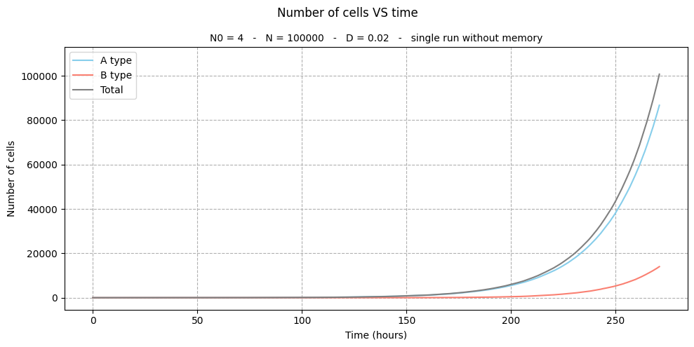

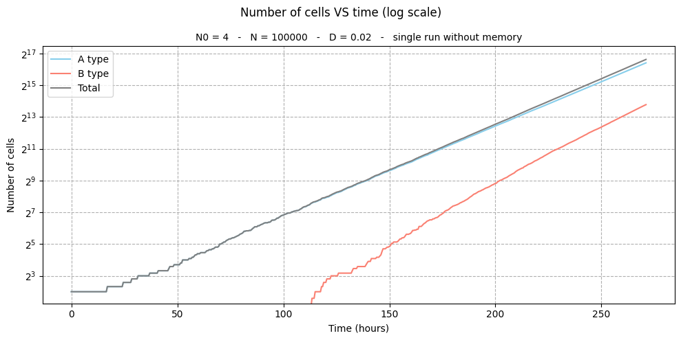

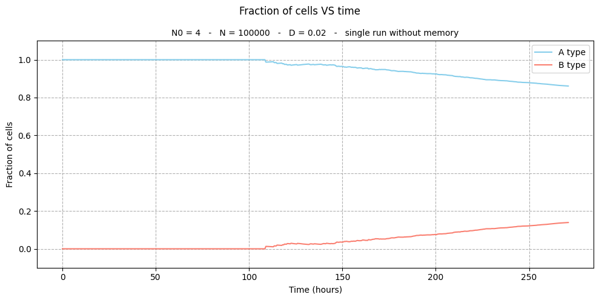

```python
time_list = [t[0] for t in history['F1']]
total_A = np.zeros(len(time_list))
total_B = np.zeros(len(time_list))
for data in history.values():
    total_A += [t[1] for t in data]
    total_B += [t[2] for t in data]
frac_A = []
frac_B = []
for i, _ in enumerate(time_list):
    frac_A.append(total_A[i] / (total_A[i] + total_B[i]))
    frac_B.append(total_B[i] / (total_A[i] + total_B[i]))

#plot 1
plt.figure(figsize=(10, 5))
plt.plot(time_list, total_A, label=f'A type', color='skyblue')
plt.plot(time_list, total_B, label=f'B type', color='salmon')
plt.plot(time_list, total_A + total_B, label=f'Total' , color='gray')
plt.xlabel("Time (hours)")
plt.ylabel("Number of cells")
plt.suptitle('Number of cells VS time')
if MEMORY == True:
    plt.title( f'N0 = {N_INITIAL_CELLS}   -   N = {N_FINAL_CELLS}   -   D = {DIFF_PERC}   -   single run with memory', fontsize=10)
elif MEMORY == False:
    plt.title( f'N0 = {N_INITIAL_CELLS}   -   N = {N_FINAL_CELLS}   -   D = {DIFF_PERC}   -   single run without memory', fontsize=10)
plt.legend()
plt.grid(linestyle='--')
plt.tight_layout()
plt.ylim((np.float64(-5376.0), np.float64(112896.0))) # pasted from memory to have plots in the same scale
plt.show()

#plot 2
plt.figure(figsize=(10, 5))
plt.plot(time_list, total_A, label=f'A type', color='skyblue')
plt.plot(time_list, total_B, label=f'B type', color='salmon')
plt.plot(time_list, total_A + total_B, label=f'Total' , color='gray')
plt.xlabel("Time (hours)")
plt.ylabel("Number of cells")
plt.suptitle('Number of cells VS time (log scale)')
if MEMORY == True:
    plt.title( f'N0 = {N_INITIAL_CELLS}   -   N = {N_FINAL_CELLS}   -   D = {DIFF_PERC}   -   single run with memory', fontsize=10)
elif MEMORY == False:
    plt.title( f'N0 = {N_INITIAL_CELLS}   -   N = {N_FINAL_CELLS}   -   D = {DIFF_PERC}   -   single run without memory', fontsize=10)
plt.legend()
plt.grid(linestyle='--')
plt.yscale('log', base=2)
plt.tight_layout()
plt.ylim((np.float64(2.402085867582824), np.float64(179044.39046251963))) # pasted from memory to have plots in the same scale
plt.show()

#plot 3
plt.figure(figsize=(10, 5))
#plt.plot(time_list, np.array(frac_A) + np.array(frac_B), label=f'Total' , color='gray') # just to check
plt.plot(time_list, frac_A, label=f'A type', color='skyblue')
plt.plot(time_list, frac_B, label=f'B type', color='salmon')
plt.xlabel("Time (hours)")
plt.ylabel("Fraction of cells")
plt.suptitle('Fraction of cells VS time')
if MEMORY == True:
    plt.title( f'N0 = {N_INITIAL_CELLS}   -   N = {N_FINAL_CELLS}   -   D = {DIFF_PERC}   -   single run with memory', fontsize=10)
elif MEMORY == False:
    plt.title( f'N0 = {N_INITIAL_CELLS}   -   N = {N_FINAL_CELLS}   -   D = {DIFF_PERC}   -   single run without memory', fontsize=10)
plt.legend()
plt.grid(linestyle='--')
plt.ylim(-0.1, 1.1)
plt.yticks([0, 0.2, 0.4, 0.6, 0.8, 1])
plt.tight_layout()
plt.show()
```

### Plots 5 - time evolutions of averages/stds/ranges between families

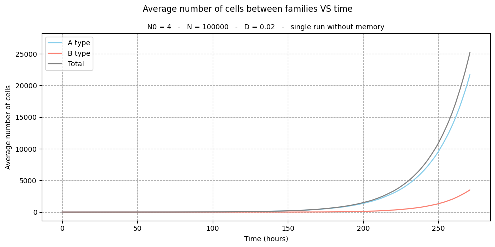

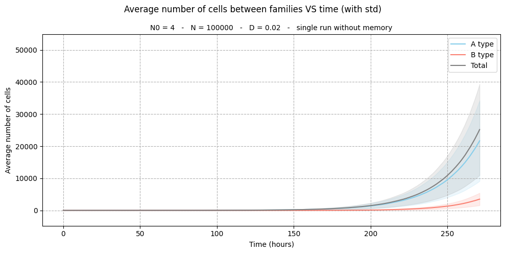

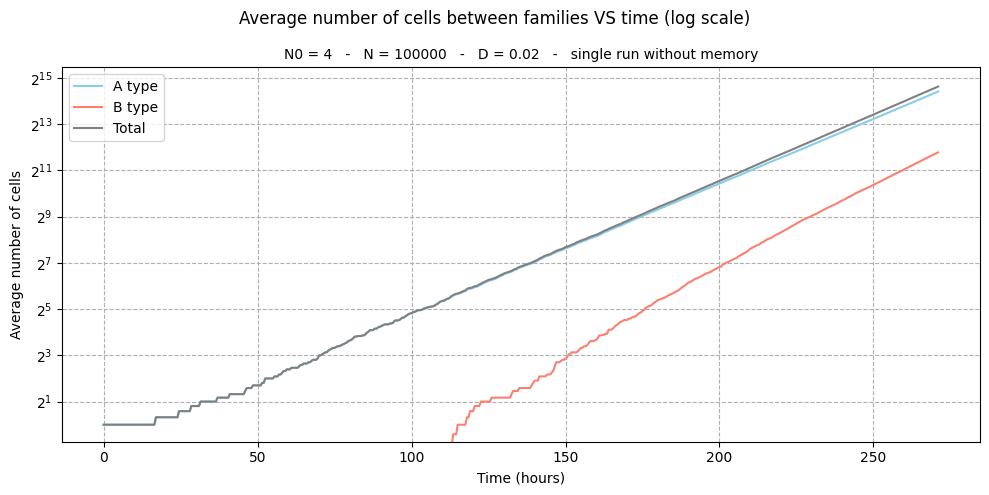

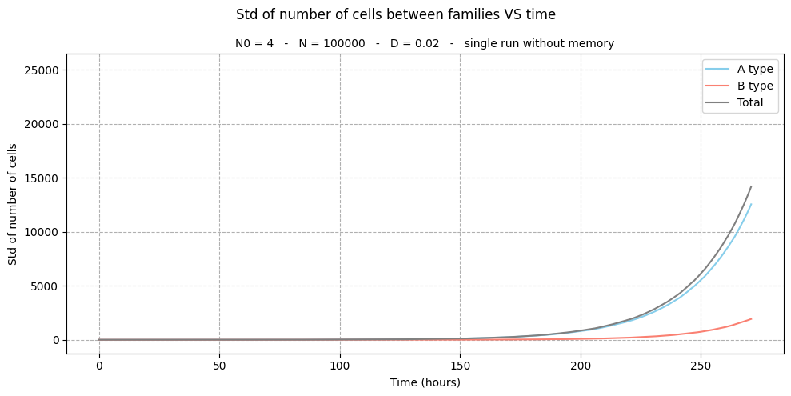

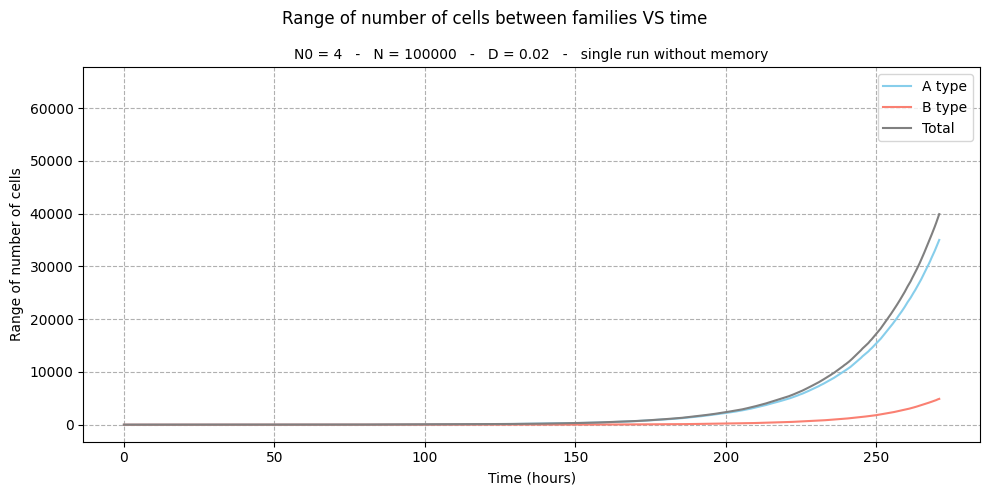

```python
time_list = [t[0] for t in history['F1']]
N_A_fam, N_B_fam, N_tot_fam = [], [], []
for data in history.values():
    N_A_fam.append([t[1] for t in data])
    N_B_fam.append([t[2] for t in data])
    N_tot_fam.append([t[1] + t[2] for t in data])
N_A_fam_T = np.array(N_A_fam).T
N_B_fam_T = np.array(N_B_fam).T
N_tot_fam_T = np.array(N_tot_fam).T
ranges_A, ranges_B, ranges_tot = [], [], []
means_A, means_B, means_tot = [], [], []
stds_A, stds_B, stds_tot = [], [], []
for i in range(len(time_list)):
    ranges_A.append( max(N_A_fam_T[i]) - min(N_A_fam_T[i]) )
    ranges_B.append( max(N_B_fam_T[i]) - min(N_B_fam_T[i]) )
    ranges_tot.append( max(N_tot_fam_T[i]) - min(N_tot_fam_T[i]) )
    means_A.append( np.mean(N_A_fam_T[i]) )
    means_B.append( np.mean(N_B_fam_T[i]) )
    means_tot.append( np.mean(N_tot_fam_T[i]) )
    stds_A.append( np.std(N_A_fam_T[i]) )
    stds_B.append( np.std(N_B_fam_T[i]) )
    stds_tot.append( np.std(N_tot_fam_T[i]) )

#plot 1
plt.figure(figsize=(10, 5))
plt.plot(time_list, means_A, label='A type', color='skyblue')
plt.plot(time_list, means_B, label='B type', color='salmon')
plt.plot(time_list, means_tot, label='Total', color='grey')
plt.xlabel('Time (hours)')
plt.ylabel('Average number of cells')
plt.suptitle('Average number of cells between families VS time')
if MEMORY == True:
    plt.title( f'N0 = {N_INITIAL_CELLS}   -   N = {N_FINAL_CELLS}   -   D = {DIFF_PERC}   -   single run with memory', fontsize=10)
elif MEMORY == False:
    plt.title( f'N0 = {N_INITIAL_CELLS}   -   N = {N_FINAL_CELLS}   -   D = {DIFF_PERC}   -   single run without memory', fontsize=10)
plt.legend()
plt.grid(linestyle='--')
plt.tight_layout()
plt.ylim((np.float64(-1344.0), np.float64(28224.0))) # pasted from memory to have plots in the same scale
plt.show()

#plot 2
plt.figure(figsize=(10, 5))
plt.plot(time_list, means_A, label='A type', color='skyblue')
plt.fill_between(time_list, np.array(means_A) - np.array(stds_A), np.array(means_A) + np.array(stds_A), color=plt.gca().lines[-1].get_color(), alpha=0.15)
plt.plot(time_list, means_B, label='B type', color='salmon')
plt.fill_between(time_list, np.array(means_B) - np.array(stds_B), np.array(means_B) + np.array(stds_B), color=plt.gca().lines[-1].get_color(), alpha=0.15)
plt.plot(time_list, means_tot, label='Total', color='grey')
plt.fill_between(time_list, np.array(means_tot) - np.array(stds_tot), np.array(means_tot) + np.array(stds_tot), color=plt.gca().lines[-1].get_color(), alpha=0.15)
plt.xlabel('Time (hours)')
plt.ylabel('Average number of cells')
plt.suptitle('Average number of cells between families VS time (with std)')
if MEMORY == True:
    plt.title( f'N0 = {N_INITIAL_CELLS}   -   N = {N_FINAL_CELLS}   -   D = {DIFF_PERC}   -   single run with memory', fontsize=10)
elif MEMORY == False:
    plt.title( f'N0 = {N_INITIAL_CELLS}   -   N = {N_FINAL_CELLS}   -   D = {DIFF_PERC}   -   single run without memory', fontsize=10)
plt.legend()
plt.grid(linestyle='--')
plt.tight_layout()
plt.ylim((np.float64(-4786.813642358575), np.float64(54822.05721822674))) # pasted from memory to have plots in the same scale
plt.show()

#plot 3
plt.figure(figsize=(10, 5))
plt.plot(time_list, means_A, label='A type', color='skyblue')
plt.plot(time_list, means_B, label='B type', color='salmon')
plt.plot(time_list, means_tot, label='Total', color='grey')
plt.xlabel('Time (hours)')
plt.ylabel('Average number of cells')
plt.suptitle('Average number of cells between families VS time (log scale)')
if MEMORY == True:
    plt.title( f'N0 = {N_INITIAL_CELLS}   -   N = {N_FINAL_CELLS}   -   D = {DIFF_PERC}   -   single run with memory', fontsize=10)
elif MEMORY == False:
    plt.title( f'N0 = {N_INITIAL_CELLS}   -   N = {N_FINAL_CELLS}   -   D = {DIFF_PERC}   -   single run without memory', fontsize=10)
plt.legend()
plt.grid(linestyle='--')
plt.yscale('log', base=2)
plt.tight_layout()
plt.ylim((np.float64(0.600521466895706), np.float64(44761.09761563002))) # pasted from memory to have plots in the same scale
plt.show()

#plot 4
plt.figure(figsize=(10, 5))
plt.plot(time_list, stds_A, label='A type', color='skyblue')
plt.plot(time_list, stds_B, label='B type', color='salmon')
plt.plot(time_list, stds_tot, label='Total', color='grey')
plt.xlabel('Time (hours)')
plt.ylabel('Std of number of cells')
plt.suptitle('Std of number of cells between families VS time')
if MEMORY == True:
    plt.title( f'N0 = {N_INITIAL_CELLS}   -   N = {N_FINAL_CELLS}   -   D = {DIFF_PERC}   -   single run with memory', fontsize=10)
elif MEMORY == False:
    plt.title( f'N0 = {N_INITIAL_CELLS}   -   N = {N_FINAL_CELLS}   -   D = {DIFF_PERC}   -   single run without memory', fontsize=10)
plt.legend()
plt.grid(linestyle='--')
plt.tight_layout()
plt.ylim((np.float64(-1261.6281544100068), np.float64(26494.19124261014))) # pasted from memory to have plots in the same scale
plt.show()

#plot 5
plt.figure(figsize=(10, 5))
plt.plot(time_list, ranges_A, label='A type', color='skyblue')
plt.plot(time_list, ranges_B, label='B type', color='salmon')
plt.plot(time_list, ranges_tot, label='Total', color='grey')
plt.xlabel('Time (hours)')
plt.ylabel('Range of number of cells')
plt.suptitle('Range of number of cells between families VS time')
if MEMORY == True:
    plt.title( f'N0 = {N_INITIAL_CELLS}   -   N = {N_FINAL_CELLS}   -   D = {DIFF_PERC}   -   single run with memory', fontsize=10)
elif MEMORY == False:
    plt.title( f'N0 = {N_INITIAL_CELLS}   -   N = {N_FINAL_CELLS}   -   D = {DIFF_PERC}   -   single run without memory', fontsize=10)
plt.legend()
plt.grid(linestyle='--')
plt.tight_layout()
plt.ylim((np.float64(-3225.6000000000004), np.float64(67737.6))) # pasted from memory to have plots in the same scale
plt.show()
```

[figure not shown]

[figure not shown]

[figure not shown]

[figure not shown]

```python
time_list = [t[0] for t in history['F1']]
frac_A_fam, frac_B_fam = [], []
for data in history.values():
    frac_A_fam.append([t[1] / (t[1] + t[2]) for t in data])
    frac_B_fam.append([t[2] / (t[1] + t[2]) for t in data])
frac_A_fam_T = np.array(frac_A_fam).T
frac_B_fam_T = np.array(frac_B_fam).T
ranges_A, ranges_B = [], []
means_A, means_B = [], []
stds_A, stds_B = [], []
for i in range(len(time_list)):
    ranges_A.append( max(frac_A_fam_T[i]) - min(frac_A_fam_T[i]) )
    ranges_B.append( max(frac_B_fam_T[i]) - min(frac_B_fam_T[i]) )
    means_A.append( np.mean(frac_A_fam_T[i]) )
    means_B.append( np.mean(frac_B_fam_T[i]) )
    stds_A.append( np.std(frac_A_fam_T[i]) )
    stds_B.append( np.std(frac_B_fam_T[i]) )

#plot 1
plt.figure(figsize=(10, 5))
plt.plot(time_list, means_A, label='A type', color='skyblue')
plt.plot(time_list, means_B, label='B type', color='salmon')
plt.xlabel('Time (hours)')
plt.ylabel('Average fraction of cells')
plt.suptitle('Average fraction of cells between families VS time')
if MEMORY == True:
    plt.title( f'N0 = {N_INITIAL_CELLS}   -   N = {N_FINAL_CELLS}   -   D = {DIFF_PERC}   -   single run with memory', fontsize=10)
elif MEMORY == False:
    plt.title( f'N0 = {N_INITIAL_CELLS}   -   N = {N_FINAL_CELLS}   -   D = {DIFF_PERC}   -   single run without memory', fontsize=10)
plt.legend()
plt.grid(linestyle='--')
plt.ylim(-0.1, 1.1)
plt.yticks([0, 0.2, 0.4, 0.6, 0.8, 1])
plt.tight_layout()
plt.show()

#plot 2
plt.figure(figsize=(10, 5))
plt.plot(time_list, means_A, label='A type', color='skyblue')
plt.fill_between(time_list, np.array(means_A) - np.array(stds_A), np.array(means_A) + np.array(stds_A), color=plt.gca().lines[-1].get_color(), alpha=0.15)
plt.plot(time_list, means_B, label='B type', color='salmon')
plt.fill_between(time_list, np.array(means_B) - np.array(stds_B), np.array(means_B) + np.array(stds_B), color=plt.gca().lines[-1].get_color(), alpha=0.15)
plt.xlabel('Time (hours)')
plt.ylabel('Average fraction of cells')
plt.suptitle('Average fraction of cells between families VS time (with std)')
if MEMORY == True:
    plt.title( f'N0 = {N_INITIAL_CELLS}   -   N = {N_FINAL_CELLS}   -   D = {DIFF_PERC}   -   single run with memory', fontsize=10)
elif MEMORY == False:
    plt.title( f'N0 = {N_INITIAL_CELLS}   -   N = {N_FINAL_CELLS}   -   D = {DIFF_PERC}   -   single run without memory', fontsize=10)
plt.legend()
plt.grid(linestyle='--')
plt.ylim(-0.1, 1.1)
plt.yticks([0, 0.2, 0.4, 0.6, 0.8, 1])
plt.tight_layout()
plt.show()

#plot 3
plt.figure(figsize=(10, 5))
plt.plot(time_list, stds_B, label='B type', color='salmon')
plt.plot(time_list, stds_A, label='A type', color='skyblue')
#A and B same exact values
plt.xlabel('Time (hours)')
plt.ylabel('Std of fraction of cells')
plt.suptitle('Std of fraction of cells between families VS time')
if MEMORY == True:
    plt.title( f'N0 = {N_INITIAL_CELLS}   -   N = {N_FINAL_CELLS}   -   D = {DIFF_PERC}   -   single run with memory', fontsize=10)
elif MEMORY == False:
    plt.title( f'N0 = {N_INITIAL_CELLS}   -   N = {N_FINAL_CELLS}   -   D = {DIFF_PERC}   -   single run without memory', fontsize=10)
plt.legend()
plt.grid(linestyle='--')
plt.ylim(-0.1, 1.1)
plt.yticks([0, 0.2, 0.4, 0.6, 0.8, 1])
plt.tight_layout()
plt.show()

#plot 4
plt.figure(figsize=(10, 5))
plt.plot(time_list, ranges_B, label='B type', color='salmon')
plt.plot(time_list, ranges_A, label='A type', color='skyblue')
#A and B same exact values
plt.xlabel('Time (hours)')
plt.ylabel('Range of fraction of cells')
plt.suptitle('Range of fraction of cells between families VS time')
if MEMORY == True:
    plt.title( f'N0 = {N_INITIAL_CELLS}   -   N = {N_FINAL_CELLS}   -   D = {DIFF_PERC}   -   single run with memory', fontsize=10)
elif MEMORY == False:
    plt.title( f'N0 = {N_INITIAL_CELLS}   -   N = {N_FINAL_CELLS}   -   D = {DIFF_PERC}   -   single run without memory', fontsize=10)
plt.legend()
plt.grid(linestyle='--')
plt.ylim(-0.1, 1.1)
plt.yticks([0, 0.2, 0.4, 0.6, 0.8, 1])
plt.tight_layout()
plt.show()
```

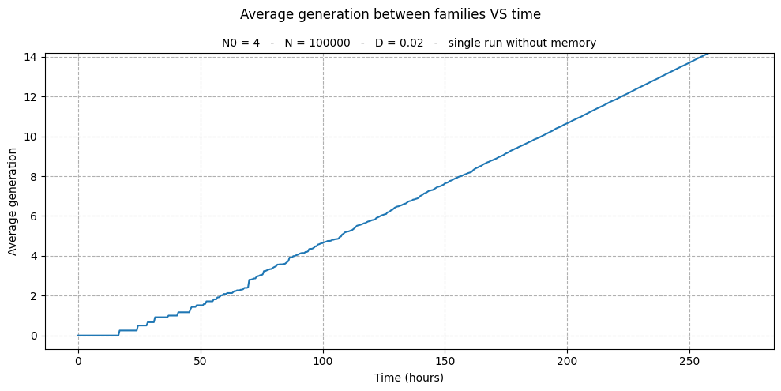

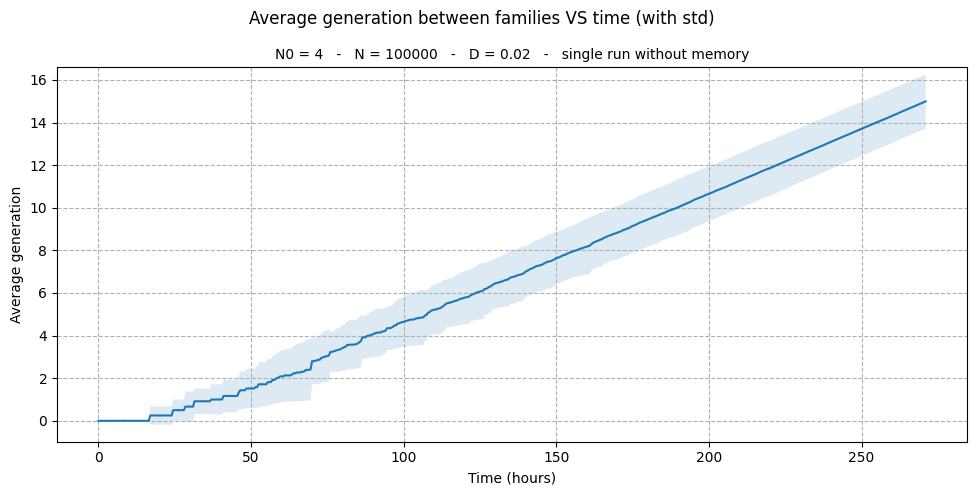

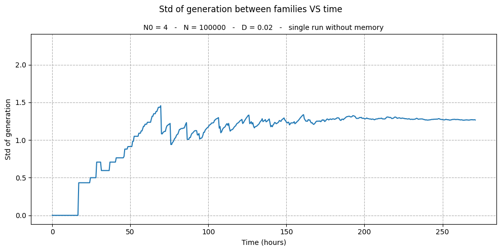

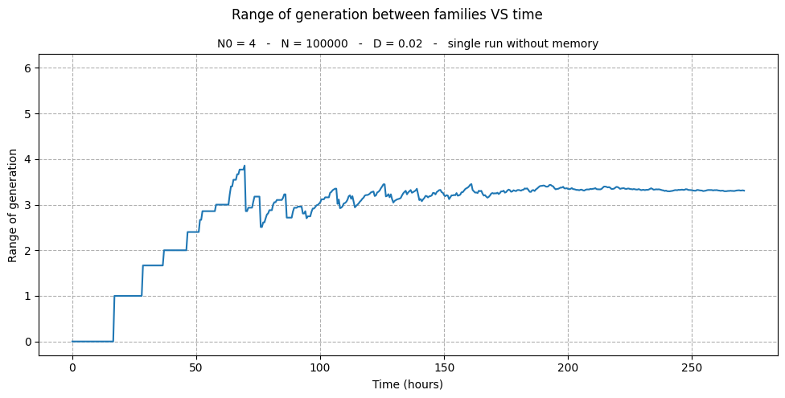

```python
time_list = [t[0] for t in history['F1']]
gen_fam = []
for data in history.values():
    gen_fam.append([t[3] for t in data])
gen_fam_T = np.array(gen_fam).T
ranges = []
means = []
stds = []
for i in range(len(time_list)):
    ranges.append( max(gen_fam_T[i]) - min(gen_fam_T[i]) )
    means.append( np.mean(gen_fam_T[i]) )
    stds.append( np.std(gen_fam_T[i]) )

#plot 1
plt.figure(figsize=(10, 5))
plt.plot(time_list, means)
plt.xlabel('Time (hours)')
plt.ylabel('Average generation')
plt.suptitle('Average generation between families VS time')
if MEMORY == True:
    plt.title( f'N0 = {N_INITIAL_CELLS}   -   N = {N_FINAL_CELLS}   -   D = {DIFF_PERC}   -   single run with memory', fontsize=10)
elif MEMORY == False:
    plt.title( f'N0 = {N_INITIAL_CELLS}   -   N = {N_FINAL_CELLS}   -   D = {DIFF_PERC}   -   single run without memory', fontsize=10)
plt.grid(linestyle='--')
plt.tight_layout()
plt.ylim((np.float64(-0.675), np.float64(14.175))) # pasted from memory to have plots in the same scale
plt.show()

#plot 2
plt.figure(figsize=(10, 5))
plt.plot(time_list, means)
plt.fill_between(time_list, np.array(means) - np.array(stds), np.array(means) + np.array(stds), alpha=0.15)
plt.xlabel('Time (hours)')
plt.ylabel('Average generation')
plt.suptitle('Average generation between families VS time (with std)')
if MEMORY == True:
    plt.title( f'N0 = {N_INITIAL_CELLS}   -   N = {N_FINAL_CELLS}   -   D = {DIFF_PERC}   -   single run with memory', fontsize=10)
elif MEMORY == False:
    plt.title( f'N0 = {N_INITIAL_CELLS}   -   N = {N_FINAL_CELLS}   -   D = {DIFF_PERC}   -   single run without memory', fontsize=10)
plt.grid(linestyle='--')
plt.tight_layout()
plt.ylim((np.float64(-0.9817277293607263), np.float64(16.590002874946425))) # pasted from memory to have plots in the same scale
plt.show()

#plot 3
plt.figure(figsize=(10, 5))
plt.plot(time_list, stds)
plt.xlabel('Time (hours)')
plt.ylabel('Std of generation')
plt.suptitle('Std of generation between families VS time')
if MEMORY == True:
    plt.title( f'N0 = {N_INITIAL_CELLS}   -   N = {N_FINAL_CELLS}   -   D = {DIFF_PERC}   -   single run with memory', fontsize=10)
elif MEMORY == False:
    plt.title( f'N0 = {N_INITIAL_CELLS}   -   N = {N_FINAL_CELLS}   -   D = {DIFF_PERC}   -   single run without memory', fontsize=10)
plt.grid(linestyle='--')
plt.tight_layout()
ymin, ymax = plt.ylim()
#plt.yticks(range(int(ymin), int(ymax) + 1))
plt.ylim((np.float64(-0.114564392373896), np.float64(2.405852239851816))) # pasted from memory to have plots in the same scale
plt.show()

#plot 4
plt.figure(figsize=(10, 5))
plt.plot(time_list, ranges)
plt.xlabel('Time (hours)')
plt.ylabel('Range of generation')
plt.suptitle('Range of generation between families VS time')
if MEMORY == True:
    plt.title( f'N0 = {N_INITIAL_CELLS}   -   N = {N_FINAL_CELLS}   -   D = {DIFF_PERC}   -   single run with memory', fontsize=10)
elif MEMORY == False:
    plt.title( f'N0 = {N_INITIAL_CELLS}   -   N = {N_FINAL_CELLS}   -   D = {DIFF_PERC}   -   single run without memory', fontsize=10)
plt.grid(linestyle='--')
plt.tight_layout()
ymin, ymax = plt.ylim()
#plt.yticks(range(int(ymin), int(ymax) + 1))
plt.ylim((np.float64(-0.30000000000000004), np.float64(6.3))) # pasted from memory to have plots in the same scale
plt.show()
```

## Multiple runs simulation

```python
TIME_STEP = 0.5
N_INITIAL_CELLS = 4
N_FINAL_CELLS = 100000
DIFF_PERC = 0.02
MU = 2.83
SIGMA = 0.42

N_RUNS = 1000

fams, histories, times, d = multiple_runs(N_RUNS, MEMORY, TIME_STEP, N_INITIAL_CELLS, N_FINAL_CELLS, DIFF_PERC, MU, SIGMA)
```

### Print

```python
print(f'--On average simulations stopped at time: {round(np.mean(times), 2)} (std = {round(np.std(times), 2)}, min = {min(times)}, max = {max(times)})\n')

print(f'--Average number of final cells:')
print(f'A = {round(d['N_type_A_mean'], 2)} (std = {round(d['N_type_A_std'], 2)}), B = {round(d['N_type_B_mean'], 2)} (std = {round(d['N_type_B_std'], 2)}), Total = {round(d['N_type_A_mean'] + d['N_type_B_mean'], 2)} (std = {round(d['N_tot_std'], 2)})') # (media della somma = somma delle medie)
print('--Average number of final cells per family:')
for i, f in enumerate(fams[0].keys()):
    print(f'{f}: A = {round(d['N_type_A_mean_fam'][i], 2)} (std = {round(d['N_type_A_std_fam'][i], 2)}), B = {round(d['N_type_B_mean_fam'][i], 2)} (std = {round(d['N_type_B_std_fam'][i], 2)}), Total = {round(d['N_type_A_mean_fam'][i] + d['N_type_B_mean_fam'][i], 2)} (std = {round(d['N_tot_std_fam'][i])})') # (media della somma = somma delle medie)
print(f'(Mean between families: A = {round(np.mean(d['N_type_A_mean_fam']), 2)}, B = {round(np.mean(d['N_type_B_mean_fam']), 2)}, Total = {round(np.mean(d['N_type_A_mean_fam'] + d['N_type_B_mean_fam']), 2)})') # mean of averages on runs, meaning average both on runs and on families
print(f'(Std between families: A = {round(np.std(d['N_type_A_mean_fam']), 2)}, B = {round(np.std(d['N_type_B_mean_fam']), 2)}, Total = {round(np.std(d['N_type_A_mean_fam'] + d['N_type_B_mean_fam']), 2)})\n') # std of averages on runs

print(f'--Average fraction of final cells:')
print(f'A = {round(d['frac_type_A_mean'], 2)} (std = {round(d['frac_type_A_std'], 2)}), B = {round(d['frac_type_B_mean'], 2)} (std = {round(d['frac_type_B_std'], 2)})')
print('--Average fraction of final cells per family:')
for i, f in enumerate(fams[0].keys()):
    print(f'{f}: A = {round(d['frac_type_A_mean_fam'][i], 2)} (std = {round(d['frac_type_A_std_fam'][i], 2)}), B = {round(d['frac_type_B_mean_fam'][i], 2)} (std = {round(d['frac_type_B_std_fam'][i], 2)})')
print(f'(Mean between families: A = {round(np.mean(d['frac_type_A_mean_fam']), 2)}, B = {round(np.mean(d['frac_type_B_mean_fam']), 2)})') # mean of averages on runs, meaning average both on runs and on families
print(f'(Std between families: A = {round(np.std(d['frac_type_A_mean_fam']), 3)}, B = {round(np.std(d['frac_type_B_mean_fam']), 3)})\n') # std of averages on runs

if MEMORY == True:
    gen_mean_fam = []
    for f in fams[0].keys():
        gens = []
        for i in range(N_RUNS):
            gens.append(fams[i][f]['current_gen'])
        gen_mean_fam.append(np.mean(gens))
    print('--Average generation of final cells per family (=average number of division rounds performed per family):')
    for i, f in enumerate(fams[0].keys()):
        print(f'{f}: {round(gen_mean_fam[i], 2)}')
    print(f'(Mean between families: {round(np.mean(gen_mean_fam), 2)})') # mean of averages on runs, meaning average both on runs and on families
    print(f'(Std between families: {round(np.std(gen_mean_fam), 2)})\n') # std of averages on runs
if MEMORY==False:
    gen_mean_fam = []
    for f in fams[0].keys():
        gens = []
        for i in range(N_RUNS):
            gens.append(histories[i][f][-1][4])
        gen_mean_fam.append(np.mean(gens))
    print('--Average of average generation of final cells per family (=average of average number of division rounds performed per family):') # average of average, meaning average both on cells of a family and on runs
    for i, f in enumerate(fams[0].keys()):
        print(f'{f}: {round(gen_mean_fam[i], 2)}')
    print(f'(Mean between families: {round(np.mean(gen_mean_fam), 2)})') # mean of averages on runs of averages on cells of a family, meaning average on cells of a family, on runs and on families
    print(f'(Std between families: {round(np.std(gen_mean_fam), 2)})\n') # std of averages on runs of averages on cells of a family
```

```
--On average simulations stopped at time: 260.73 (std = 5.13, min = 244.5, max = 281.5)

--Average number of final cells:
A = 79130.08 (std = 6903.87), B = 20862.04 (std = 6867.74), Total = 99992.11 (std = 587.17)
--Average number of final cells per family:
F1: A = 19853.66 (std = 7807.78), B = 5316.0 (std = 4141.01), Total = 25169.66 (std = 8893)
F2: A = 19597.74 (std = 7354.71), B = 5030.46 (std = 3536.68), Total = 24628.2 (std = 8491)
F3: A = 19610.57 (std = 7833.27), B = 5258.02 (std = 4253.38), Total = 24868.59 (std = 8968)
F4: A = 20068.11 (std = 7499.3), B = 5257.56 (std = 4093.75), Total = 25325.67 (std = 8585)
(Mean between families: A = 19782.52, B = 5215.51, Total = 24998.03)
(Std between families: A = 193.86, B = 109.45, Total = 269.41)

--Average fraction of final cells:
A = 0.79 (std = 0.07), B = 0.21 (std = 0.07)
--Average fraction of final cells per family:
F1: A = 0.79 (std = 0.14), B = 0.21 (std = 0.14)
F2: A = 0.8 (std = 0.13), B = 0.2 (std = 0.13)
F3: A = 0.79 (std = 0.14), B = 0.21 (std = 0.14)
F4: A = 0.8 (std = 0.13), B = 0.2 (std = 0.13)
(Mean between families: A = 0.79, B = 0.21)
(Std between families: A = 0.003, B = 0.003)

--Average of average generation of final cells per family (=average of average number of division rounds performed per family):
F1: 1.54
F2: 1.53
F3: 1.53
F4: 1.53
(Mean between families: 1.53)
(Std between families: 0.0)
```

### Plots 0 - total time evolutions of all runs

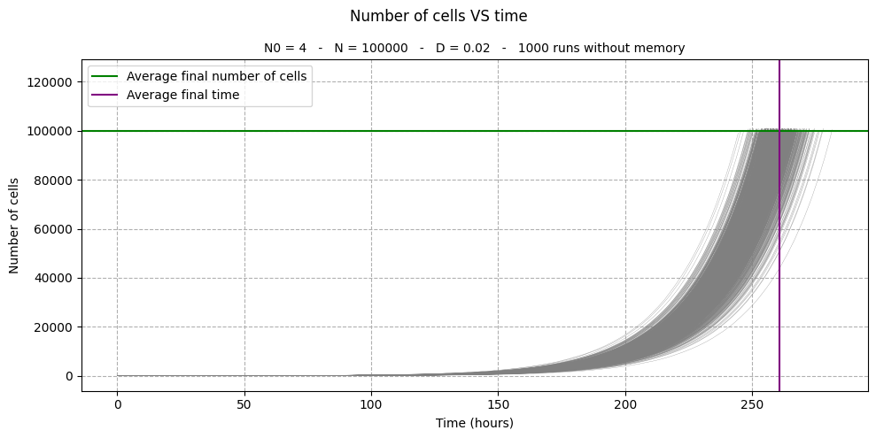

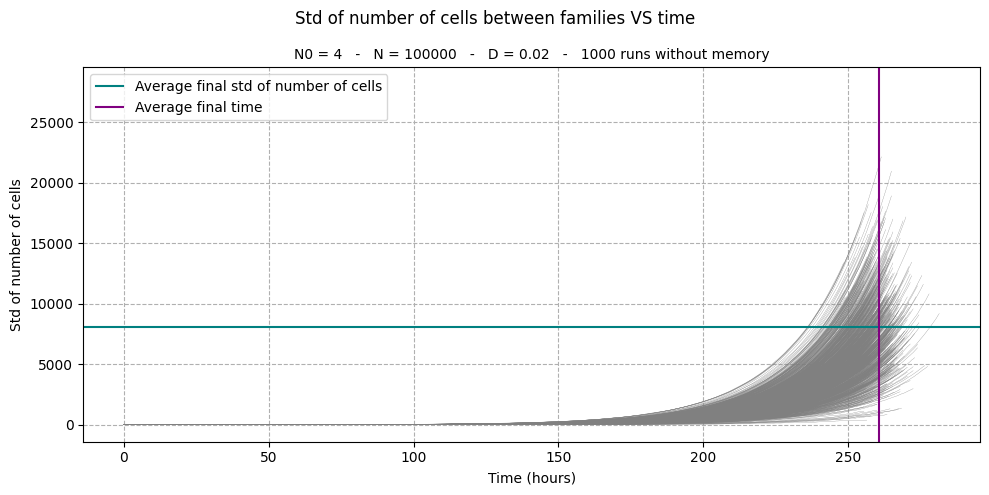

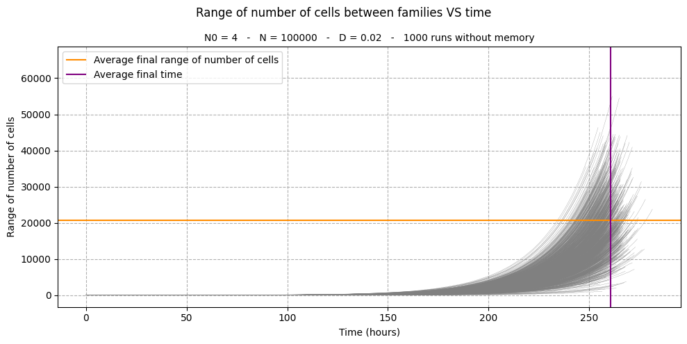

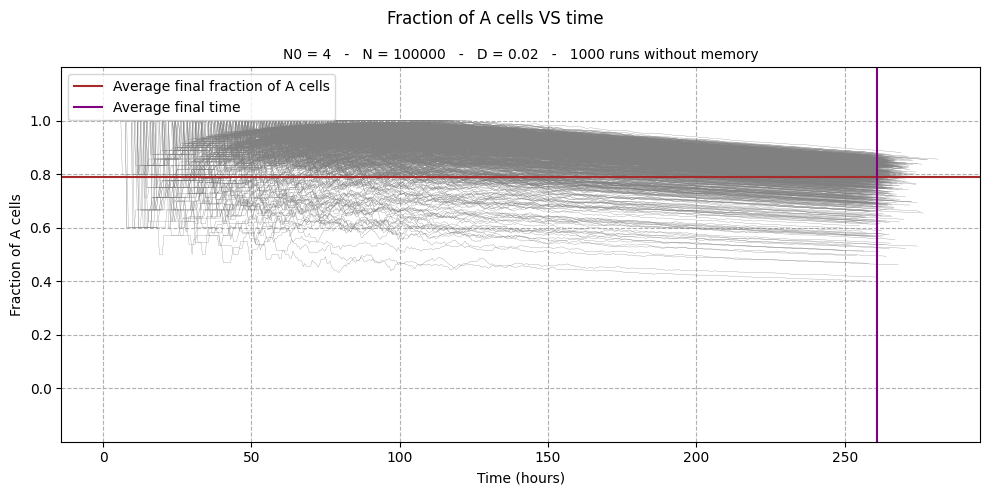

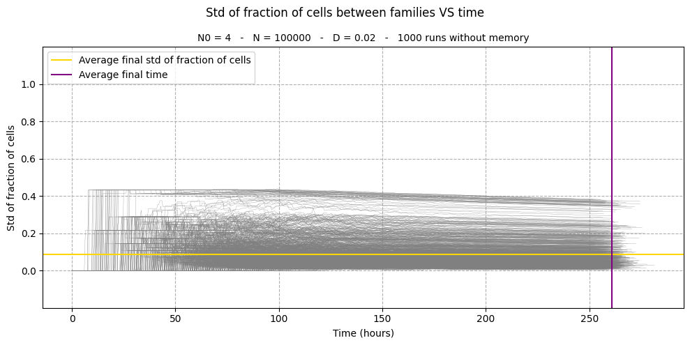

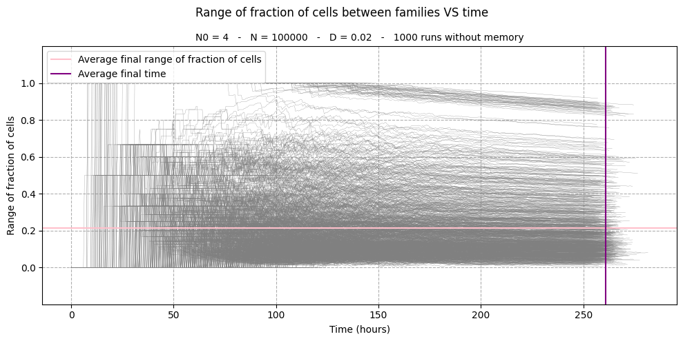

```python
# plot 1
plt.figure(figsize=(10, 5))
for history in histories:
    time_list = [t[0] for t in history['F1']]
    N_list = np.zeros(len(time_list))
    for data in history.values():
        N_list += [t[1]+t[2] for t in data]
    plt.plot(time_list, N_list, color='grey', linewidth=0.2)
plt.axhline(y = d['N_type_A_mean'] + d['N_type_B_mean'], color='green', label='Average final number of cells')
plt.axvline(x = np.mean(times), color='purple', label='Average final time')
plt.xlabel("Time (hours)")
plt.ylabel("Number of cells")
plt.suptitle('Number of cells VS time')
if MEMORY == True:
    plt.title( f'N0 = {N_INITIAL_CELLS}   -   N = {N_FINAL_CELLS}   -   D = {DIFF_PERC}   -   {N_RUNS} runs with memory', fontsize=10)
elif MEMORY == False:
    plt.title( f'N0 = {N_INITIAL_CELLS}   -   N = {N_FINAL_CELLS}   -   D = {DIFF_PERC}   -   {N_RUNS} runs without memory', fontsize=10)
plt.legend()
plt.grid(linestyle='--')
plt.tight_layout()
plt.ylim((np.float64(-6139.8), np.float64(129023.8))) # pasted from memory to have plots in the same scale
plt.show()

# plot 2
plt.figure(figsize=(10, 5))
for history in histories:
    time_list = [t[0] for t in history['F1']]
    N_tot_fam = []
    for data in history.values():
        N_tot_fam.append([t[1] + t[2] for t in data])
    stdfam_N_list = np.std(N_tot_fam, axis=0)
    plt.plot(time_list, stdfam_N_list, color='grey', linewidth=0.2)
plt.axhline(y = d['stdfam_num_mean'], color='teal', label='Average final std of number of cells')
plt.axvline(x = np.mean(times), color='purple', label='Average final time')
plt.xlabel("Time (hours)")
plt.ylabel('Std of number of cells')
plt.suptitle('Std of number of cells between families VS time')
if MEMORY == True:
    plt.title( f'N0 = {N_INITIAL_CELLS}   -   N = {N_FINAL_CELLS}   -   D = {DIFF_PERC}   -   {N_RUNS} runs with memory', fontsize=10)
elif MEMORY == False:
    plt.title( f'N0 = {N_INITIAL_CELLS}   -   N = {N_FINAL_CELLS}   -   D = {DIFF_PERC}   -   {N_RUNS} runs without memory', fontsize=10)
plt.legend()
plt.grid(linestyle='--')
plt.tight_layout()
plt.ylim((np.float64(-1406.0313510018188), np.float64(29526.658371038196))) # pasted from memory to have plots in the same scale
plt.show()

# plot 3
plt.figure(figsize=(10, 5))
for history in histories:
    time_list = [t[0] for t in history['F1']]
    N_tot_fam = []
    for data in history.values():
        N_tot_fam.append([t[1] + t[2] for t in data])
    N_tot_fam_T = np.array(N_tot_fam).T
    range_N_list = []
    for i in range(len(time_list)):
        range_N_list.append( max(N_tot_fam_T[i]) - min(N_tot_fam_T[i]) )
    plt.plot(time_list, range_N_list, color='grey', linewidth=0.2)
plt.axhline(y = d['range_num_mean'], color='darkorange', label='Average final range of number of cells')
plt.axvline(x = np.mean(times), color='purple', label='Average final time')
plt.xlabel("Time (hours)")
plt.ylabel('Range of number of cells')
plt.suptitle('Range of number of cells between families VS time')
if MEMORY == True:
    plt.title( f'N0 = {N_INITIAL_CELLS}   -   N = {N_FINAL_CELLS}   -   D = {DIFF_PERC}   -   {N_RUNS} runs with memory', fontsize=10)
elif MEMORY == False:
    plt.title( f'N0 = {N_INITIAL_CELLS}   -   N = {N_FINAL_CELLS}   -   D = {DIFF_PERC}   -   {N_RUNS} runs without memory', fontsize=10)
plt.legend()
plt.grid(linestyle='--')
plt.tight_layout()
plt.ylim((np.float64(-3270.4), np.float64(68678.4))) # pasted from memory to have plots in the same scale
plt.show()

# plot 4
plt.figure(figsize=(10, 5))
for history in histories:
    time_list = [t[0] for t in history['F1']]
    N_A_list = np.zeros(len(time_list))
    N_B_list = np.zeros(len(time_list))
    for data in history.values():
        N_A_list += [t[1] for t in data]
        N_B_list += [t[2] for t in data]
    frac_A_list = []
    for i, _ in enumerate(time_list):
        frac_A_list.append(N_A_list[i] / (N_A_list[i] + N_B_list[i]))
    plt.plot(time_list, frac_A_list, color='grey', linewidth=0.2)
plt.axhline(y = d['frac_type_A_mean'], color='brown', label='Average final fraction of A cells')
plt.axvline(x = np.mean(times), color='purple', label='Average final time')
plt.xlabel("Time (hours)")
plt.ylabel("Fraction of A cells")
plt.suptitle('Fraction of A cells VS time')
if MEMORY == True:
    plt.title( f'N0 = {N_INITIAL_CELLS}   -   N = {N_FINAL_CELLS}   -   D = {DIFF_PERC}   -   {N_RUNS} runs with memory', fontsize=10)
elif MEMORY == False:
    plt.title( f'N0 = {N_INITIAL_CELLS}   -   N = {N_FINAL_CELLS}   -   D = {DIFF_PERC}   -   {N_RUNS} runs without memory', fontsize=10)
plt.legend()
plt.grid(linestyle='--')
plt.ylim(-0.2, 1.2)
plt.yticks([0, 0.2, 0.4, 0.6, 0.8, 1])
plt.tight_layout()
plt.show()

# plot 5
plt.figure(figsize=(10, 5))
for history in histories:
    time_list = [t[0] for t in history['F1']]
    frac_A_fam = []
    for data in history.values():
        frac_A_fam.append([t[1] / (t[1] + t[2]) for t in data])
    stdfam_frac_A_list = np.std(frac_A_fam, axis=0)
    plt.plot(time_list, stdfam_frac_A_list, color='grey', linewidth=0.2)
plt.axhline(y = d['stdfam_frac_mean'], color='gold', label='Average final std of fraction of cells')
plt.axvline(x = np.mean(times), color='purple', label='Average final time')
plt.xlabel("Time (hours)")
plt.ylabel('Std of fraction of cells')
plt.suptitle('Std of fraction of cells between families VS time')
if MEMORY == True:
    plt.title( f'N0 = {N_INITIAL_CELLS}   -   N = {N_FINAL_CELLS}   -   D = {DIFF_PERC}   -   {N_RUNS} runs with memory', fontsize=10)
elif MEMORY == False:
    plt.title( f'N0 = {N_INITIAL_CELLS}   -   N = {N_FINAL_CELLS}   -   D = {DIFF_PERC}   -   {N_RUNS} runs without memory', fontsize=10)
plt.legend()
plt.grid(linestyle='--')
plt.ylim(-0.2, 1.2)
plt.yticks([0, 0.2, 0.4, 0.6, 0.8, 1])
plt.tight_layout()
plt.show()

# plot 6
plt.figure(figsize=(10, 5))
for history in histories:
    time_list = [t[0] for t in history['F1']]
    frac_A_fam = []
    for data in history.values():
        frac_A_fam.append([t[1] / (t[1] + t[2]) for t in data])
    frac_A_fam_T = np.array(frac_A_fam).T
    range_frac_A_list = []
    for i in range(len(time_list)):
        range_frac_A_list.append( max(frac_A_fam_T[i]) - min(frac_A_fam_T[i]) )
    plt.plot(time_list, range_frac_A_list, color='grey', linewidth=0.2)
plt.axhline(y = d['range_frac_mean'], color='pink', label='Average final range of fraction of cells')
plt.axvline(x = np.mean(times), color='purple', label='Average final time')
plt.xlabel("Time (hours)")
plt.ylabel('Range of fraction of cells')
plt.suptitle('Range of fraction of cells between families VS time')
if MEMORY == True:
    plt.title( f'N0 = {N_INITIAL_CELLS}   -   N = {N_FINAL_CELLS}   -   D = {DIFF_PERC}   -   {N_RUNS} runs with memory', fontsize=10)
elif MEMORY == False:
    plt.title( f'N0 = {N_INITIAL_CELLS}   -   N = {N_FINAL_CELLS}   -   D = {DIFF_PERC}   -   {N_RUNS} runs without memory', fontsize=10)
plt.legend()
plt.grid(linestyle='--')
plt.ylim(-0.2, 1.2)
plt.yticks([0, 0.2, 0.4, 0.6, 0.8, 1])
plt.tight_layout()
plt.show()
```